# Bank_Marketing

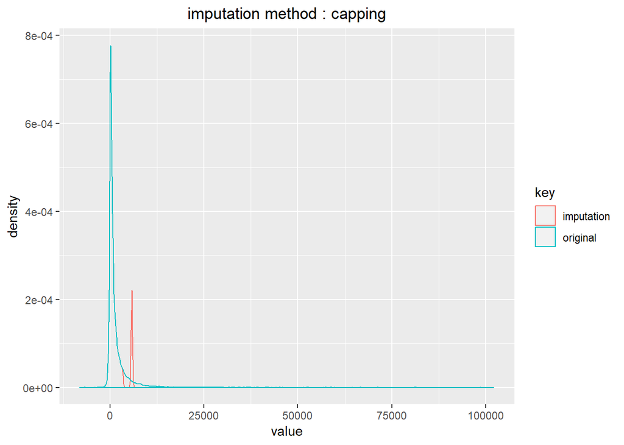

```r
plot(balance_imp)
```

```r
bank <-cbind(bank,balance_imp)

campaign_imp <- imputate_outlier(bank, campaign, method = "capping")
summary(campaign_imp)
```

```
## Impute outliers with capping
##
## * Information of Imputation (before vs after)
##              Original   Imputation
## n        4.521100e+04 4.521100e+04
## na       0.000000e+00 0.000000e+00
## mean     2.763841e+00 2.527770e+00
## sd       3.098021e+00 1.947076e+00
## se_mean  1.457009e-02 9.157162e-03
## IQR      2.000000e+00 2.000000e+00
## skewness 4.898650e+00 1.588853e+00
## kurtosis 3.924965e+01 1.793558e+00
## p00      1.000000e+00 1.000000e+00
## p01      1.000000e+00 1.000000e+00
## p05      1.000000e+00 1.000000e+00
## p10      1.000000e+00 1.000000e+00
## p20      1.000000e+00 1.000000e+00
## p25      1.000000e+00 1.000000e+00
## p30      1.000000e+00 1.000000e+00
## p40      2.000000e+00 2.000000e+00
## p50      2.000000e+00 2.000000e+00
## p60      2.000000e+00 2.000000e+00
## p70      3.000000e+00 3.000000e+00
## p75      3.000000e+00 3.000000e+00
## p80      4.000000e+00 4.000000e+00
## p90      5.000000e+00 5.000000e+00
## p95      8.000000e+00 8.000000e+00
## p99      1.600000e+01 8.000000e+00
## p100     6.300000e+01 8.000000e+00
```

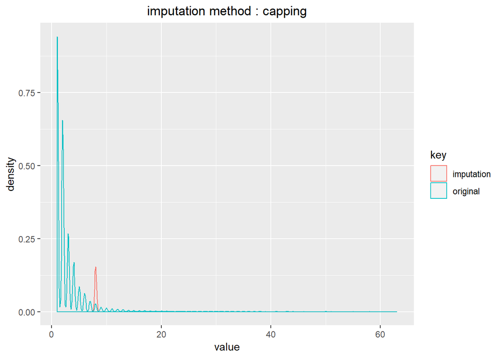

```r
plot(campaign_imp)
```

```r
bank <-cbind(bank,campaign_imp)

duration_imp <- imputate_outlier(bank, duration, method = "capping")
summary(duration_imp)
```

```
## Impute outliers with capping
##
## * Information of Imputation (before vs after)
##              Original   Imputation
## n        45211.000000 4.521100e+04
## na           0.000000 0.000000e+00
## mean       258.163080 2.426671e+02
## sd         257.527812 1.957610e+02
## se_mean      1.211162 9.206703e-01
## IQR        216.000000 2.160000e+02
## skewness     3.144318 1.308020e+00
## kurtosis    18.153915 9.542390e-01
## p00          0.000000 0.000000e+00
## p01         11.000000 1.100000e+01
## p05         35.000000 3.500000e+01
## p10         58.000000 5.800000e+01
## p20         89.000000 8.900000e+01
## p25        103.000000 1.030000e+02
## p30        117.000000 1.170000e+02
## p40        147.000000 1.470000e+02
## p50        180.000000 1.800000e+02
## p60        223.000000 2.230000e+02
## p70        280.000000 2.800000e+02
## p75        319.000000 3.190000e+02
## p80        368.000000 3.680000e+02
## p90        548.000000 5.480000e+02
## p95        751.000000 7.510000e+02
## p99       1269.000000 7.510000e+02
## p100      4918.000000 7.510000e+02
```

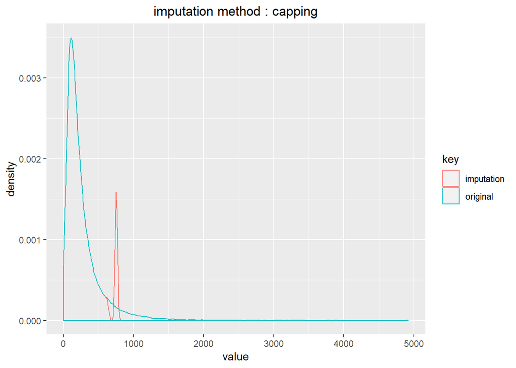

```r
plot(duration_imp)
```

```r
bank <-cbind(bank,duration_imp)

pdays_imp <- imputate_outlier(bank, pdays, method = "capping")
summary(pdays_imp)
```

```
## Impute outliers with capping
##
## * Information of Imputation (before vs after)
##               Original    Imputation
## n        45211.0000000 45211.0000000
## na           0.0000000     0.0000000
## mean        40.1978280    57.0771494
## sd         100.1287460   122.8654228
## se_mean      0.4709087     0.5778400
## IQR          0.0000000     0.0000000
## skewness     2.6157155     1.6428921
## kurtosis     6.9351952     0.6991253
## p00         -1.0000000    -1.0000000
## p01         -1.0000000    -1.0000000
## p05         -1.0000000    -1.0000000
## p10         -1.0000000    -1.0000000
## p20         -1.0000000    -1.0000000
## p25         -1.0000000    -1.0000000
## p30         -1.0000000    -1.0000000
## p40         -1.0000000    -1.0000000
## p50         -1.0000000    -1.0000000
## p60         -1.0000000    -1.0000000
## p70         -1.0000000    -1.0000000
## p75         -1.0000000    -1.0000000
## p80         -1.0000000    -1.0000000
## p90        185.0000000   317.0000000
## p95        317.0000000   317.0000000
## p99        370.0000000   317.0000000
## p100       871.0000000   317.0000000
```

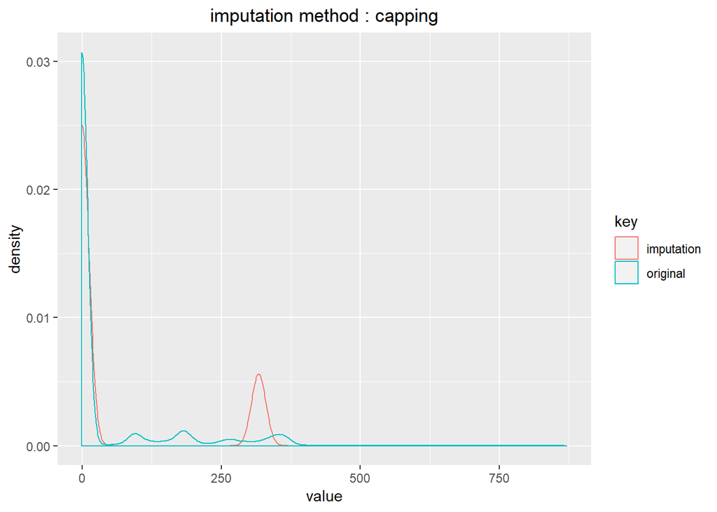

```r
plot(pdays_imp)
```

```r
bank <-cbind(bank,pdays_imp)

previous_imp <- imputate_outlier(bank, previous, method = "capping")
summary(previous_imp)
```

```
## Impute outliers with capping
##
## * Information of Imputation (before vs after)
##              Original   Imputation
## n        4.521100e+04 4.521100e+04
## na       0.000000e+00 0.000000e+00
## mean     5.803234e-01 5.478976e-01
## sd       2.303441e+00 1.159108e+00
## se_mean  1.083316e-02 5.451321e-03
## IQR      0.000000e+00 0.000000e+00
## skewness 4.184645e+01 1.642892e+00
## kurtosis 4.506861e+03 6.991253e-01
## p00      0.000000e+00 0.000000e+00
## p01      0.000000e+00 0.000000e+00
## p05      0.000000e+00 0.000000e+00
## p10      0.000000e+00 0.000000e+00
## p20      0.000000e+00 0.000000e+00
## p25      0.000000e+00 0.000000e+00
## p30      0.000000e+00 0.000000e+00
## p40      0.000000e+00 0.000000e+00
## p50      0.000000e+00 0.000000e+00
## p60      0.000000e+00 0.000000e+00
## p70      0.000000e+00 0.000000e+00
## p75      0.000000e+00 0.000000e+00
## p80      0.000000e+00 0.000000e+00
## p90      2.000000e+00 3.000000e+00
## p95      3.000000e+00 3.000000e+00
## p99      8.900000e+00 3.000000e+00
## p100     2.750000e+02 3.000000e+00
```

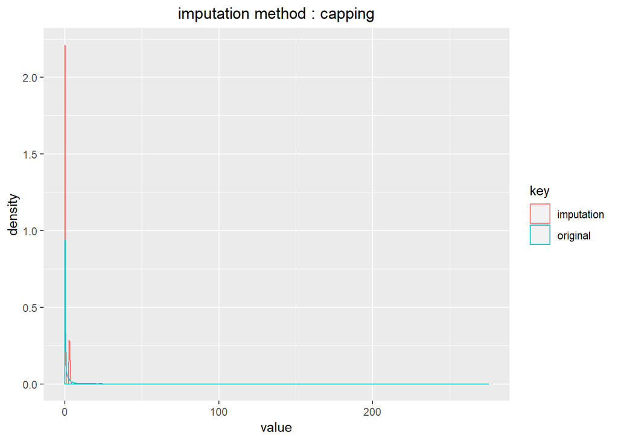

```r
plot(previous_imp)
```

```r
bank <-cbind(bank,previous_imp)
```

Box plots for Outliers minimized data: Box plots are again created with the capped data to see the distribution. Compared to the original data, these capped data distribution is good without affecting its distribution much.

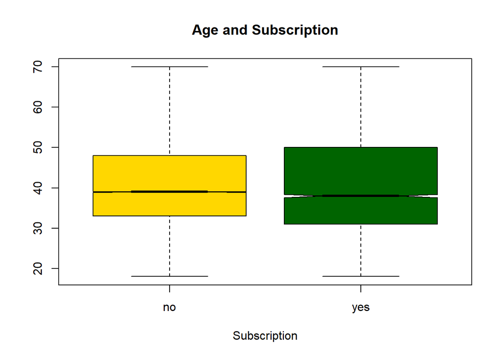

```r
#Box Plots - Imputed & Outliers minimized variables
boxplot(age_imp~y, data=bank, notch=TRUE,
        col=(c("gold","darkgreen")),
        main="Age and Subscription", xlab="Subscription")
```

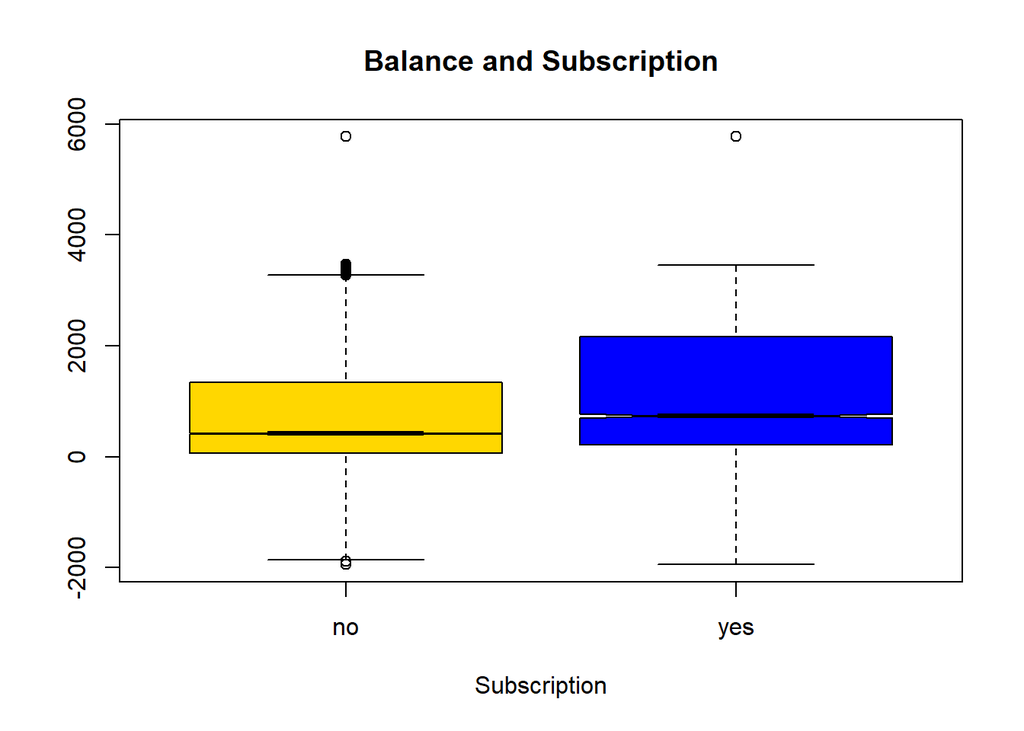

```r
boxplot(balance_imp~y, data=bank, notch=TRUE,
        col=(c("gold","blue")),
        main="Balance and Subscription", xlab="Subscription")
```

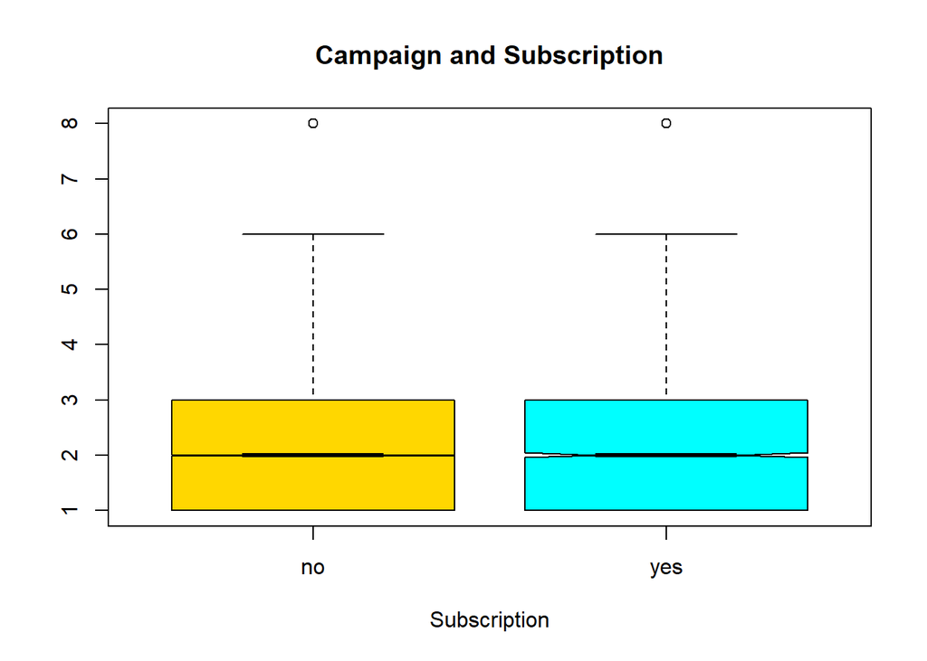

```r
boxplot(campaign_imp~y, data=bank, notch=TRUE,
        col=(c("gold","cyan")),
        main="Campaign and Subscription", xlab="Subscription")
```

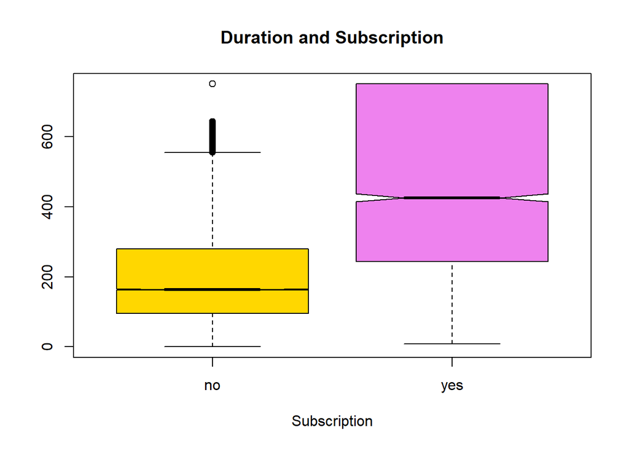

```r
boxplot(duration_imp~y, data=bank, notch=TRUE,
        col=(c("gold","violet")),
        main="Duration and Subscription", xlab="Subscription")
```

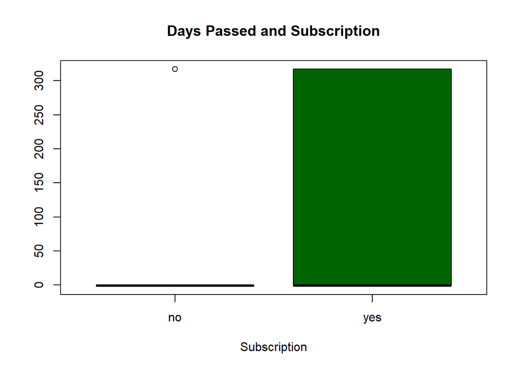

```r
boxplot(pdays_imp~y, data=bank, notch=FALSE,
        col=(c("gold","dark green")),
        main="Days Passed and Subscription", xlab="Subscription")
```

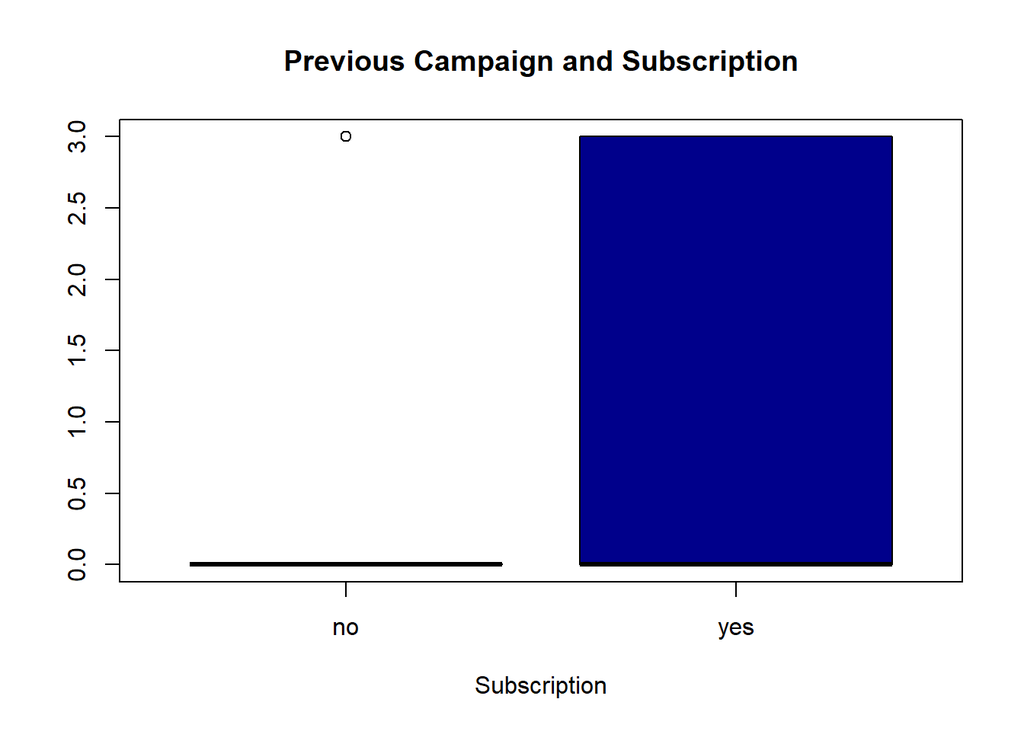

```r
boxplot(previous_imp~y, data=bank, notch=FALSE,
        col=(c("gold","dark blue")),
        main="Previous Campaign and Subscription", xlab="Subscription")
```

Category reduction in variables - Analysis by percentage and absolute numbers There are categorical variables which has more levels like Job, marital status etc. These needs to be analysed and grouped together based on the similarity of the percentage of events occurring when compared to the total of events and non-events.

```r
table(bank$job, bank$y)
```

```
##
##                   no  yes
##   admin.        4540  631
##   blue-collar   9024  708
##   entrepreneur  1364  123
##   housemaid     1131  109
##   management    8157 1301
##   retired       1748  516
##   self-employed 1392  187
##   services      3785  369
##   student        669  269
##   technician    6757  840
##   unemployed    1101  202
##   unknown        254   34
```

```r
round(prop.table(table(bank$job, bank$y),1),2)
```

```
##
##                   no  yes
##   admin.        0.88 0.12
##   blue-collar   0.93 0.07
##   entrepreneur  0.92 0.08
##   housemaid     0.91 0.09
##   management    0.86 0.14
##   retired       0.77 0.23
##   self-employed 0.88 0.12
##   services      0.91 0.09
##   student       0.71 0.29
##   technician    0.89 0.11
##   unemployed    0.84 0.16
##   unknown       0.88 0.12
```

```r
table(bank$education, bank$y)
```

```
##
##                no   yes
##   primary    6260   591
##   secondary 20752  2450
##   tertiary  11305  1996
##   unknown    1605   252
```

```r
round(prop.table(table(bank$education, bank$y),1),2)
```

```
##
##               no  yes
##   primary   0.91 0.09
##   secondary 0.89 0.11
##   tertiary  0.85 0.15
##   unknown   0.86 0.14
```

```r
table(bank$month, bank$y)
```

```
##
##          no   yes
##   apr  2355   577
##   aug  5559   688
##   dec   114   100
##   feb  2208   441
##   jan  1261   142
##   jul  6268   627
##   jun  4795   546
##   mar   229   248
##   may 12841   925
##   nov  3567   403
##   oct   415   323
##   sep   310   269
```

```r
round(prop.table(table(bank$month, bank$y),1),2)
```

```
##
##         no  yes
##   apr 0.80 0.20
##   aug 0.89 0.11
##   dec 0.53 0.47
##   feb 0.83 0.17
##   jan 0.90 0.10
##   jul 0.91 0.09
##   jun 0.90 0.10
##   mar 0.48 0.52
##   may 0.93 0.07
##   nov 0.90 0.10
##   oct 0.56 0.44
##   sep 0.54 0.46
```

```r
table(bank$marital, bank$y)
```

```
##
##               no   yes
##   divorced  4585   622
##   married  24459  2755
##   single   10878  1912
```

```r
round(prop.table(table(bank$marital, bank$y),1),2)
```

```
##
##              no  yes
##   divorced 0.88 0.12
##   married  0.90 0.10
##   single   0.85 0.15
```

```r
table(bank$poutcome, bank$y)
```

```
##
##              no   yes
##   failure  4283   618
##   other    1533   307
##   success   533   978
##   unknown 33573  3386
```

```r
round(prop.table(table(bank$poutcome, bank$y),1),2)
```

```
##
##             no  yes
##   failure 0.87 0.13
##   other   0.83 0.17
##   success 0.35 0.65
##   unknown 0.91 0.09
```

```r
table(bank$contact, bank$y)
```

```
##
##                no   yes
##   cellular  24916  4369
##   telephone  2516   390
##   unknown   12490   530
```

```r
round(prop.table(table(bank$contact, bank$y),1),2)
```

```
##
##               no  yes
##   cellular  0.85 0.15
##   telephone 0.87 0.13
##   unknown   0.96 0.04
```

```r
#Category reduction in variables by similar percentage of events using Rockchalk library

library(rockchalk)
#Combine Job levels to 4
job_level1 <-combineLevels(bank$job,c("student","retired"),newLabel=c("st_re"))
job_level2 <-combineLevels(job_level1,c("unemployed","management"),newLabel=c("une_mgmt"))
job_level3 <-combineLevels(job_level2,c("blue-collar","entrepreneur","housemaid",
                                     "services"),newLabel=c("bl_en_hm_se"))
job_level <-combineLevels(job_level3,c("admin.","self-employed","technician",
                                        "unknown"),newLabel=c("ad_sel_te_unk"))
table(job_level)
bank <-cbind(bank,job_level)
```

```r
#Combine month levels to 3
month_level1 <-combineLevels(bank$month,c("aug","jan","jun","jul","may","nov"),newLabel=c("Ja_Ma_Ju_Jul_Au_No"))
month_level2 <-combineLevels(month_level1,c("mar","sep","oct","dec"),newLabel=c("Mar_Se_Oc_De"))
month_level <-combineLevels(month_level2,c("apr","feb"),newLabel=c("Fe_Ap"))
table(month_level)
bank <-cbind(bank,month_level)
```

```r
#Combine education levels to 2
edu_level1 <-combineLevels(bank$education,c("primary","secondary"),newLabel=c("Pri_Sec"))
edu_level <-combineLevels(edu_level1,c("tertiary","unknown"),newLabel=c("ter_unk"))
table(edu_level)
bank <-cbind(bank,edu_level)
```

```r
#Combine marital levels to 2
marital_level <-combineLevels(bank$marital,c("single","divorced"),newLabel=c("Si_Di"))
table(marital_level)
bank <-cbind(bank,marital_level)
```

```r
#Combine poutcome levels to 2
poutcome_level <-combineLevels(bank$poutcome,c("failure","other","unknown"),newLabel=c("rest"))
table(poutcome_level)
bank <-cbind(bank,poutcome_level)
```

```r
#Correlation of Continuous Variables - Before Outlier reduction
cor(bank[,c(6,12,13,14,15)])
```

```
##               balance     duration    campaign        pdays     previous
## balance   1.000000000  0.021560380 -0.01457828  0.003435322  0.016673637
## duration  0.021560380  1.000000000 -0.08456950 -0.001564770  0.001203057
## campaign -0.014578279 -0.084569503  1.00000000 -0.088627668 -0.032855290
## pdays     0.003435322 -0.001564770 -0.08862767  1.000000000  0.454819635
## previous  0.016673637  0.001203057 -0.03285529  0.454819635  1.000000000
```

```r
#Correlation of Continuous Variables - After Outlier reduction
cor(bank[,c(19,20,21,22,23)])
```

```
##              balance_imp campaign_imp duration_imp   pdays_imp
## balance_imp   1.00000000  -0.02101371   0.03844600  0.05067016
## campaign_imp -0.02101371   1.00000000  -0.09887499 -0.11572108
## duration_imp  0.03844600  -0.09887499   1.00000000  0.01319840
## pdays_imp     0.05067016  -0.11572108   0.01319840  1.00000000
## previous_imp  0.05067016  -0.11572108   0.01319840  1.00000000
##              previous_imp
## balance_imp    0.05067016
## campaign_imp  -0.11572108
## duration_imp   0.01319840
## pdays_imp      1.00000000
## previous_imp   1.00000000
```

Correlation of Continuous variables after the outlier reduction shows that pdays and previous are correlated and hence one can be removed. Here I removed pdays.

Data Partition: Data has been separated to Training and Test dataset with probability of 0.5 (exactly split into two) based on the dependent variable.

```r
#Data Classification to Train and Test
library(caret)
set.seed(1234)
train <- createDataPartition(bank$y, list=FALSE) #create 2 set of data by Random sampling
train

bank.train <- bank[train, ]
bank.test <- bank[-train, ] #-train is complement to train data
```

```r
#Convert Yes No to 1 and 0 respectively
bank.train$ObsY <- ifelse (bank.train$y == "yes", 1,0)
bank.test$ObsY <- ifelse (bank.test$y == "yes", 1,0)
bank.test$ObsY <- as.integer(bank.test$ObsY)
bank.train$ObsY <- as.integer(bank.train$ObsY)
```

```r
headTail(bank.train)
```

```
##       age          job marital education default balance housing loan
## 10     43   technician  single secondary      no     593     yes   no
## 14     58   technician married   unknown      no      71     yes   no
## 17     45       admin.  single   unknown      no      13     yes   no
## 18     57  blue-collar married   primary      no      52     yes   no
## ...   ...         <NA>    <NA>      <NA>    <NA>     ...    <NA> <NA>
## 45206  25   technician  single secondary      no     505      no  yes
## 45207  51   technician married  tertiary      no     825      no   no
## 45210  57  blue-collar married secondary      no     668      no   no
## 45211  37 entrepreneur married secondary      no    2971      no   no
##         contact day month duration campaign pdays previous poutcome    y
## 10      unknown   5   may       55        1    -1        0  unknown   no
## 14      unknown   5   may       71        1    -1        0  unknown   no
## 17      unknown   5   may       98        1    -1        0  unknown   no
## 18      unknown   5   may       38        1    -1        0  unknown   no
```

[output cut: 35 more lines]

```r
headTail(bank.test)
```

```
##       age          job  marital education default balance housing loan
## 1      58   management  married  tertiary      no    2143     yes   no
## 2      44   technician   single secondary      no      29     yes   no
## 3      33 entrepreneur  married secondary      no       2     yes  yes
## 4      47  blue-collar  married   unknown      no    1506     yes   no
## ...   ...         <NA>     <NA>      <NA>    <NA>     ...    <NA> <NA>
## 45200  34  blue-collar   single secondary      no    1475     yes   no
## 45204  23      student   single  tertiary      no     113      no   no
## 45208  71      retired divorced   primary      no    1729      no   no
## 45209  72      retired  married secondary      no    5715      no   no
##        contact day month duration campaign pdays previous poutcome    y
## 1      unknown   5   may      261        1    -1        0  unknown   no
## 2      unknown   5   may      151        1    -1        0  unknown   no
## 3      unknown   5   may       76        1    -1        0  unknown   no
## 4      unknown   5   may       92        1    -1        0  unknown   no
```

[output cut: 35 more lines]

```r
summary(bank.train)
```

```
##       age                 job           marital          education
##  Min.   :18.00   blue-collar:4858   divorced: 2633   primary  : 3408
##  1st Qu.:33.00   management :4719   married :13568   secondary:11625
##  Median :39.00   technician :3795   single  : 6405   tertiary : 6686
##  Mean   :40.95   admin.     :2580                    unknown  :  887
##  3rd Qu.:48.00   services   :2128
##  Max.   :95.00   retired    :1107
##                  (Other)    :3419
##  default        balance       housing      loan            contact
##  no :22210   Min.   : -6847   no :10041   no :19013   cellular :14616
##  yes:  396   1st Qu.:    76   yes:12565   yes: 3593   telephone: 1466
##              Median :   453                           unknown  : 6524
##              Mean   :  1360
##              3rd Qu.:  1430
##              Max.   :102127
##
##       day            month         duration         campaign
##  Min.   : 1.00   may    :6857   Min.   :   0.0   Min.   : 1.000
##  1st Qu.: 8.00   jul    :3470   1st Qu.: 103.0   1st Qu.: 1.000
##  Median :16.00   aug    :3098   Median : 180.0   Median : 2.000
##  Mean   :15.84   jun    :2740   Mean   : 257.2   Mean   : 2.789
##  3rd Qu.:21.00   nov    :1953   3rd Qu.: 318.0   3rd Qu.: 3.000
##  Max.   :31.00   apr    :1412   Max.   :3881.0   Max.   :63.000
##                  (Other):3076
##      pdays           previous          poutcome       y
##  Min.   : -1.00   Min.   : 0.0000   failure: 2432   no :19961
##  1st Qu.: -1.00   1st Qu.: 0.0000   other  :  909   yes: 2645
##  Median : -1.00   Median : 0.0000   success:  784
##  Mean   : 39.97   Mean   : 0.5834   unknown:18481
##  3rd Qu.: -1.00   3rd Qu.: 0.0000
##  Max.   :871.00   Max.   :58.0000
##
##     age_imp       balance_imp     campaign_imp    duration_imp
##  Min.   :18.00   Min.   :-1941   Min.   :1.000   Min.   :  0.0
##  1st Qu.:33.00   1st Qu.:   76   1st Qu.:1.000   1st Qu.:103.0
##  Median :39.00   Median :  453   Median :2.000   Median :180.0
##  Mean   :40.75   Mean   : 1172   Mean   :2.543   Mean   :241.9
##  3rd Qu.:48.00   3rd Qu.: 1430   3rd Qu.:3.000   3rd Qu.:318.0
##  Max.   :70.00   Max.   : 5768   Max.   :8.000   Max.   :751.0
##
```

[output cut: 9 more lines]

```
##  Ja_Ma_Ju_Jul_Au_No:18846   Pri_Sec:15033   married:13568
##  Mar_Se_Oc_De      : 1029   ter_unk: 7573   Si_Di  : 9038
##  Fe_Ap             : 2731
##
##
##
##
##  poutcome_level       ObsY
##  success:  784   Min.   :0.000
##  rest   :21822   1st Qu.:0.000
##                  Median :0.000
##                  Mean   :0.117
##                  3rd Qu.:0.000
##                  Max.   :1.000
##
```

```r
summary(bank.test)
```

```
##       age                 job           marital          education
##  Min.   :18.00   blue-collar:4874   divorced: 2574   primary  : 3443
##  1st Qu.:33.00   management :4739   married :13646   secondary:11577
##  Median :39.00   technician :3802   single  : 6385   tertiary : 6615
##  Mean   :40.93   admin.     :2591                    unknown  :  970
##  3rd Qu.:48.00   services   :2026
##  Max.   :95.00   retired    :1157
##                  (Other)    :3416
##  default        balance      housing      loan            contact
##  no :22186   Min.   :-8019   no :10040   no :18954   cellular :14669
##  yes:  419   1st Qu.:   69   yes:12565   yes: 3651   telephone: 1440
##              Median :  444                           unknown  : 6496
##              Mean   : 1365
##              3rd Qu.: 1423
##              Max.   :98417
##
##       day            month         duration         campaign
##  Min.   : 1.00   may    :6909   Min.   :   0.0   Min.   : 1.000
##  1st Qu.: 8.00   jul    :3425   1st Qu.: 103.0   1st Qu.: 1.000
##  Median :16.00   aug    :3149   Median : 180.0   Median : 2.000
##  Mean   :15.77   jun    :2601   Mean   : 259.2   Mean   : 2.739
##  3rd Qu.:21.00   nov    :2017   3rd Qu.: 319.0   3rd Qu.: 3.000
##  Max.   :31.00   apr    :1520   Max.   :4918.0   Max.   :58.000
##                  (Other):2984
##      pdays           previous           poutcome       y
##  Min.   : -1.00   Min.   :  0.0000   failure: 2469   no :19961
##  1st Qu.: -1.00   1st Qu.:  0.0000   other  :  931   yes: 2644
##  Median : -1.00   Median :  0.0000   success:  727
##  Mean   : 40.42   Mean   :  0.5772   unknown:18478
##  3rd Qu.: -1.00   3rd Qu.:  0.0000
##  Max.   :842.00   Max.   :275.0000
##
##     age_imp       balance_imp     campaign_imp    duration_imp
##  Min.   :18.00   Min.   :-1944   Min.   :1.000   Min.   :  0.0
##  1st Qu.:33.00   1st Qu.:   69   1st Qu.:1.000   1st Qu.:103.0
##  Median :39.00   Median :  444   Median :2.000   Median :180.0
##  Mean   :40.74   Mean   : 1178   Mean   :2.512   Mean   :243.4
##  3rd Qu.:48.00   3rd Qu.: 1423   3rd Qu.:3.000   3rd Qu.:319.0
##  Max.   :70.00   Max.   : 5768   Max.   :8.000   Max.   :751.0
##
```

[output cut: 9 more lines]

```
##  Ja_Ma_Ju_Jul_Au_No:18776   Pri_Sec:15020   married:13646
##  Mar_Se_Oc_De      :  979   ter_unk: 7585   Si_Di  : 8959
##  Fe_Ap             : 2850
##
##
##
##
##  poutcome_level       ObsY
##  success:  727   Min.   :0.000
##  rest   :21878   1st Qu.:0.000
##                  Median :0.000
##                  Mean   :0.117
##                  3rd Qu.:0.000
##                  Max.   :1.000
##
```

Logistic regression with original data (unstandardized) is performed to analyse the significant variable. For every n level of categorical variable, R automatically creates n-1 dummy variable.

```r
#Logistic Regression - Original Data
bank.glm <- glm(y ~ age + job + marital + education + default
                + balance + housing + loan + contact + day
                + month + duration + campaign + pdays + previous
                + poutcome, data = bank.train, family = "binomial")
summary(bank.glm)
```

```
##
## Call:
## glm(formula = y ~ age + job + marital + education + default +
##     balance + housing + loan + contact + day + month + duration +
##     campaign + pdays + previous + poutcome, family = "binomial",
##     data = bank.train)
##
## Deviance Residuals:
##     Min       1Q   Median       3Q      Max
## -4.9144  -0.3752  -0.2510  -0.1485   3.5216
##
## Coefficients:
##                      Estimate Std. Error z value Pr(>|z|)
## (Intercept)        -2.318e+00  2.604e-01  -8.900  < 2e-16 ***
## age                -4.333e-03  3.137e-03  -1.381  0.16720
## jobblue-collar     -4.108e-01  1.050e-01  -3.911 9.20e-05 ***
## jobentrepreneur    -3.672e-01  1.818e-01  -2.020  0.04339 *
## jobhousemaid       -5.240e-01  1.894e-01  -2.766  0.00567 **
## jobmanagement      -1.471e-01  1.039e-01  -1.416  0.15672
## jobretired          2.675e-01  1.411e-01   1.897  0.05789 .
## jobself-employed   -7.208e-02  1.549e-01  -0.465  0.64176
## jobservices        -6.474e-02  1.147e-01  -0.565  0.57240
## jobstudent          4.427e-01  1.527e-01   2.899  0.00374 **
## jobtechnician      -1.139e-01  9.802e-02  -1.162  0.24541
## jobunemployed      -1.146e-01  1.527e-01  -0.750  0.45309
## jobunknown         -6.853e-01  3.733e-01  -1.836  0.06639 .
## maritalmarried     -1.551e-01  8.293e-02  -1.870  0.06153 .
## maritalsingle      -3.267e-02  9.548e-02  -0.342  0.73223
## educationsecondary  8.450e-02  9.091e-02   0.930  0.35260
## educationtertiary   2.601e-01  1.053e-01   2.470  0.01352 *
## educationunknown    2.087e-02  1.531e-01   0.136  0.89153
## defaultyes         -1.249e-01  2.440e-01  -0.512  0.60874
## balance             1.745e-05  7.044e-06   2.477  0.01326 *
## housingyes         -6.944e-01  6.203e-02 -11.195  < 2e-16 ***
## loanyes            -4.447e-01  8.537e-02  -5.209 1.90e-07 ***
## contacttelephone   -2.000e-01  1.070e-01  -1.870  0.06145 .
## contactunknown     -1.668e+00  1.039e-01 -16.050  < 2e-16 ***
## day                 1.519e-02  3.509e-03   4.330 1.49e-05 ***
## monthaug           -8.444e-01  1.118e-01  -7.550 4.36e-14 ***
## monthdec            4.133e-01  2.491e-01   1.659  0.09715 .
```

[output cut: 11 more lines]

```
## pdays              -2.230e-04  4.366e-04  -0.511  0.60954
## previous            3.304e-02  1.306e-02   2.530  0.01139 *
## poutcomeother       2.277e-01  1.283e-01   1.774  0.07609 .
## poutcomesuccess     2.370e+00  1.159e-01  20.445  < 2e-16 ***
## poutcomeunknown     6.147e-02  1.363e-01   0.451  0.65189
## ---
## Signif. codes:  0 '***' 0.001 '**' 0.01 '*' 0.05 '.' 0.1 ' ' 1
##
## (Dispersion parameter for binomial family taken to be 1)
##
##     Null deviance: 16318  on 22605  degrees of freedom
## Residual deviance: 10794  on 22563  degrees of freedom
## AIC: 10880
##
## Number of Fisher Scoring iterations: 6
```